# Elite Athletes Survey Analysis

# Methods

## Survey data

- Convenience sample

Two core datasets

1. *Kobo*: socio-demographic dental and health examination, some food behavioural question. Single shot questionnaire
2. *FoodBook24*: food diary, at most 4 recalls. A recall is a day.

### Post-processings

- Kobo data is post-processed and ICDAS categories are collapsed into counts.
- FoodBook24 data is summarised at subject, meal, food group level and for this analysis we only take in account subset of the food groups
  - Analysis of the FoodBook24 showed no substantial difference in food consumption across different recalls so we take an average

### Definitions

- `total_consumptions` the total number of consumptions across all recalls
- `max_daily_consumpations` the maximum number of consumptions in a single recall (i.e. one day) across all recalls
- `mean_intake` the mean daily intake across the recalls that the food group is consumed. Note this a mean daily intake rather than a mean consumption intake. We sum across all consumptions in a day and then take an average that includes only the day of consumptions
- `max_intake` and `min_intake` maximum and minimum daily intake
- `avg_intake` the average intake that count also the day the food was not consumed

```r
library(dduh.ds)
library(tidyverse)  # data manipulation
library(cluster)    # clustering algorithms
library(factoextra) # clustering algorithms & visualization
library(caret)
config <- dduh.ds::load_config(config_file = "../../configs/ea_data.yaml")

koboData <- readRDS(config$data_repositories$kobo)
fbDentalIntake <- readRDS(config$data_repositories$foodbook_daily_intakes_dental_cario)
fbDentalIntakeLong <- readRDS(config$data_repositories$foodbook_daily_intakes_dental_long)
```

```r
selectedGroups <- fbDentalIntakeLong |>
  group_by(GroupCodeShortId, GroupCodeShort, User, MealShort) |>
  reframe(total_consumptions = max(total_consumptions)) |>
  group_by(GroupCodeShortId, GroupCodeShort) |>
  reframe(total_consumptions = sum(total_consumptions)) |>
  arrange(as.numeric(GroupCodeShortId))

knitr::kable(selectedGroups, caption = "Selected food group for dental interest")
```

Selected food group for dental interest

| GroupCodeShortId | GroupCodeShort | total_consumptions |
| --- | --- | --- |
| 1 | Beverages Sugar-sweetened | 71 |
| 2 | Biscuits, Cakes and Savouries | 119 |
| 3 | Breads, Rolls and Scones | 154 |
| 4 | Breakfast cereals | 186 |
| 5 | Fruit drinks and others | 82 |
| 6 | Yoghurt & yoghurt drinks | 77 |
| 7 | Sugars, Confectionary and Non Chocolate Confectionary | 144 |
| 8 | Sugars, Confectionary and Cereal-type Bars | 35 |
| 9 | Sugars, Confectionary and Chocolate Confectionary | 62 |
| 10 | Sugars, Confectionary and Crisps and savoury Snacks | 28 |
| 11 | Sugars, Confectionary and Jam, marmalade, lemon curd | 24 |
| 12 | Creams, Ice-creams and Desserts | 34 |
| 13 | Dietary Supplements | 246 |
| 14 | Beverages Water | 209 |
| NA | Others | 2022 |

We create a combined profile between dental examination and the summarised food diary

```r
values_cols = c(
  "sum_mean_intake",
  "avg_intake",
  "total_consumptions"
)
fbIntakeNutrientsLong <- fbDentalIntakeLong |>
  select(User,
         GroupCodeShort,
         MealShort,
         Nutrient,
         recalls,
         total_consumptions,
         mean_intake,
         max_intake,
         sum_intake) |>
  mutate(
    avg_consumptions_per_recall=total_consumptions/recalls,
    avg_intake=sum_intake/recalls
  )  |> filter(!is.na(MealShort))
```

## Outliers for food intakes

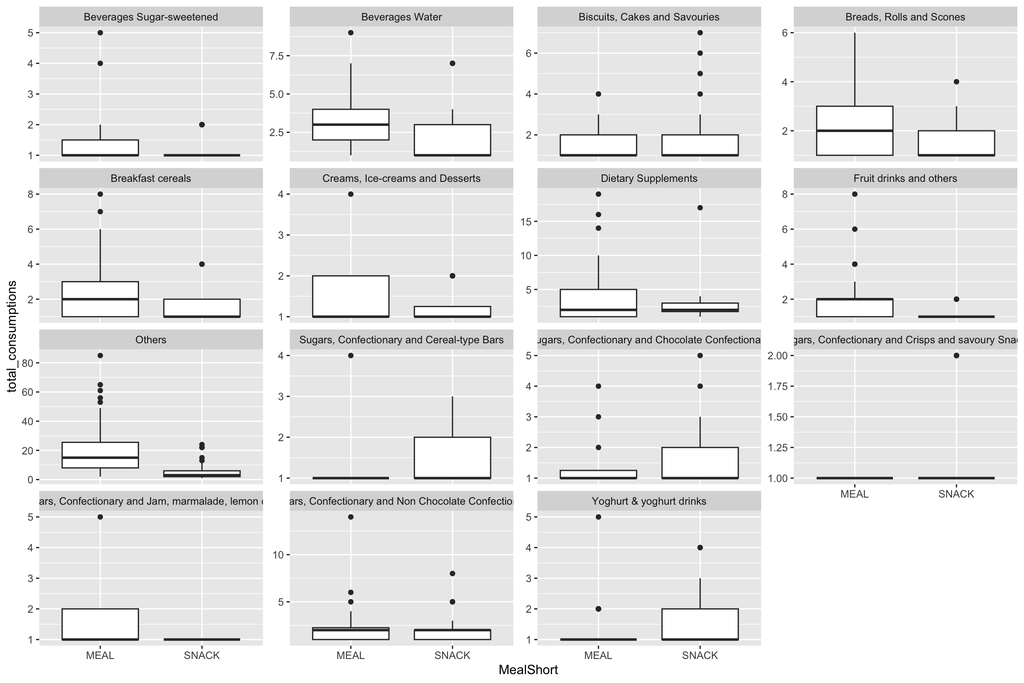

```r
dentalNutrients <- c("ENERGY_KCAL",
                     "CHO",
                     "SUGARS",
                     "STARCH"
                     )

ggplot(fbIntakeNutrientsLong |> filter(Nutrient == 'SUGARS')) +
  geom_boxplot(aes(x=MealShort, y=total_consumptions)) +
  facet_wrap(.~GroupCodeShort, scales = "free_y")
```

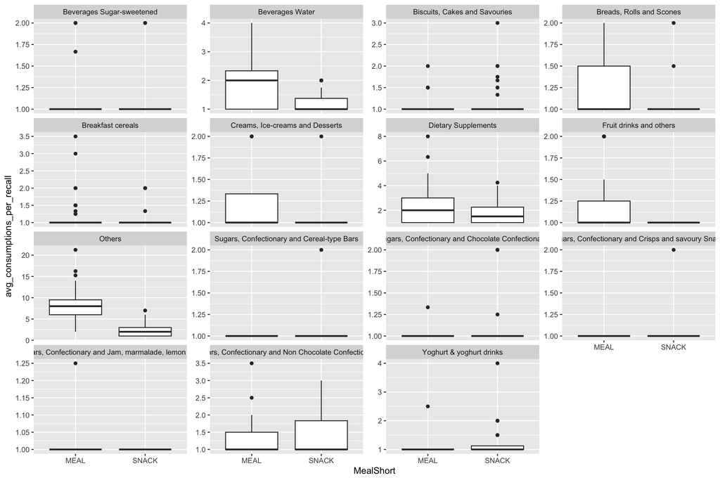

```r
ggplot(fbIntakeNutrientsLong |> filter(Nutrient == 'SUGARS')) +
  geom_boxplot(aes(x=MealShort, y=avg_consumptions_per_recall)) +
  facet_wrap(.~GroupCodeShort, scales = "free_y")
```

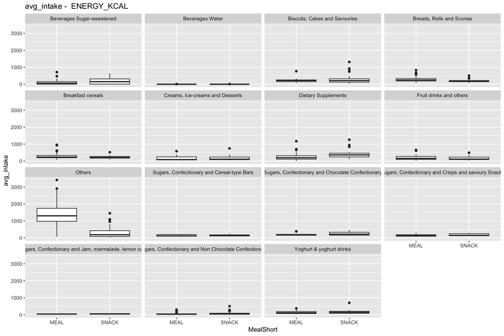

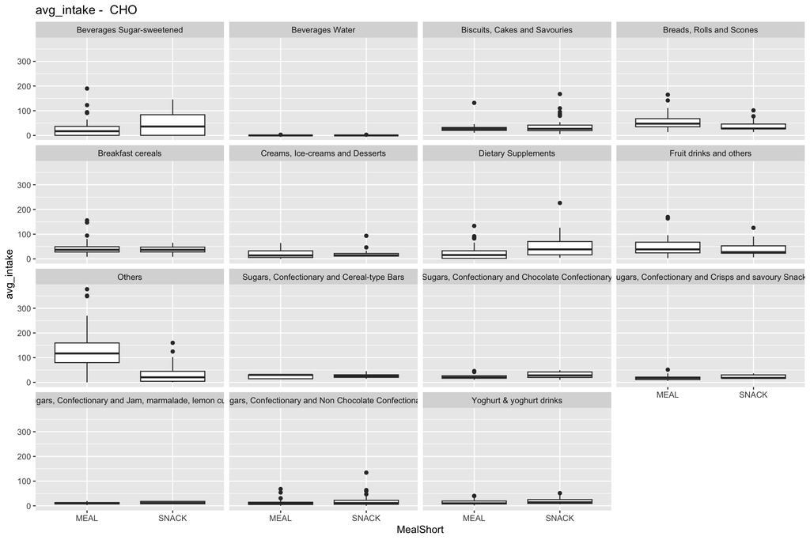

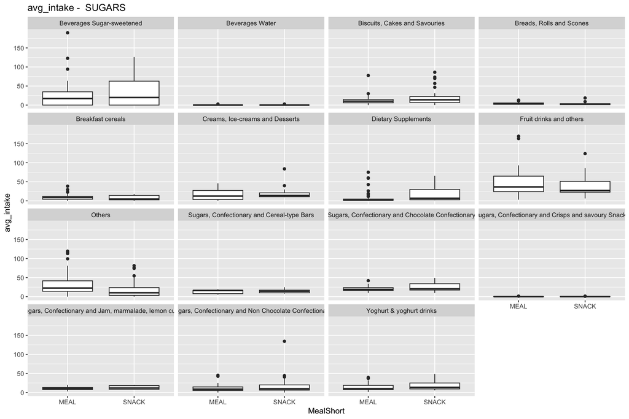

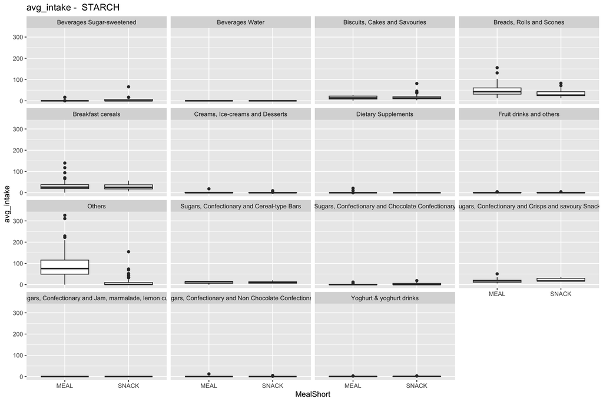

```r
for (nutrient in dentalNutrients) {
p <- ggplot(fbIntakeNutrientsLong |> filter(Nutrient == nutrient)) +
  geom_boxplot(aes(x=MealShort, y=avg_intake)) +
  facet_wrap(.~GroupCodeShort) +
  ggtitle(paste("avg_intake - ", nutrient))
print(p)
}
```

We consider only cariogenic and non cariogenic for total cosumptions Water is not counted

```r
fbIntakeNutrients <- fbDentalIntakeLong |>
  group_by(User, MealShort, Nutrient, GroupCodeShortIsCariogenic) |>
  reframe(
    total_consumptions=sum(total_consumptions),
    sum_mean_intake=sum(mean_intake),
    avg_intake=sum(sum_intake)/max(recalls)
  )  |> filter(!is.na(MealShort)) |>
  pivot_wider(
    values_from = all_of(values_cols),
    names_from = c(MealShort, Nutrient, GroupCodeShortIsCariogenic),
    values_fill = 0
  ) |>
  mutate(
    total_consumptions = total_consumptions_MEAL_CHO_Cariogenic +
      total_consumptions_MEAL_CHO_NonCariogenic
  )
```

```r
combinedProfiles <-
  koboData |>
  left_join(fbDentalIntake,
            by = join_by(participant_id == User),
            keep = TRUE) |>
  filter(!is.na(User)) |>
  select(-User)


combinedProfilesNutrients <-
    koboData |>
  left_join(fbIntakeNutrients,
            by = join_by(participant_id == User),
            keep = TRUE) |>
  filter(!is.na(User)) |>
  select(-User)
```

# Clustering

```r
is.boolean.str <- function(x) {
  isBool <- FALSE
  if (is.character(x)) {
    if (length(unique(x)) == 2) {
      isBool <- TRUE
    }
  }

  isBool
}

to.01 <- function(x) {
  as.numeric(factor(x)) - 1
}

is.cost.val <- function(x){
  length(unique(x)) == 1
}


fbConsumptionCols <- colnames(fbDentalIntake)[-1]
fbMeanStats <- fbConsumptionCols[grep("avg|total", fbConsumptionCols)]
koboDental <-
combinedProfiles |>
  select(
         # count_icdas_score_1_3,
         # count_icdas_score_1_4,
         # count_icdas_score_1_5,
         # count_icdas_score_1_6,
         # count_icdas_score_1_7,
         # count_icdas_score_1_8,
         count_icdas_score_1_3,
         count_icdas_score_1_8,
         count_icdas_score_1_97,
         count_icdas_score_2_2,
         count_icdas_score_2_3,
         count_icdas_score_2_4,
         count_icdas_score_2_5,
         count_icdas_score_2_6,
         age,
         gender,
         ethnicity,
         # tobacco,
         # smokeless_tobacco,
         # ecig_nicotine,
         # ecig_without_nicotine,
         # clean_morning,
         # clean_night,
         # clean_before_nap,
         # clean_after_nap,
         # clean_other,
         # manual_tb,
         # powered_tb,
         # interdental_aids,
         # nonfluoridated_tp,
         # fluoridated_tp,
         # mouthwash,
         # gum,
         # gum_shield,
         # last_dental_visit,
         # sport_remap,
         # trauma_status,
         # trauma_number_teeth,
         # describe_oralhealth,
         # duration_elite,
         # teeth_affect_eating,
         # teeth_affect_relaxing,
         # teeth_affect_smiling,
         # teeth_affect_participation,
         # pain_12months,
         # frequency_cakes,
         # frequency_sweets,
         # frequency_nondiet_drinks,
         # frequency_diet_drinks,
         # bars_before_competition,
         # bars_after_competition,
         # bars_during_competition,
         # bars_before_training,
         # bars_during_training,
         # bars_after_training,
         # gels_before_training,
         # gels_during_training,
         # gels_after_training,
         # gels_before_competition,
         # gels_during_competition,
         # gels_after_competition,
         # drinks_before_training,
         # drinks_during_training,
         # drinks_after_training,
         # drinks_before_competitions,
         # drinks_during_competitions,
         # drinks_after_competitions,
         # last_dental_visit,
         all_of(fbMeanStats)
         ) |>
#  mutate(sport_remap=if_else(is.na(sport_remap), 'UNKNOWN',  sport_remap)) |>
  #mutate(across(where(is.numeric), function(x){(x-min(x))/(max(x)-min(x))})) |>
  mutate(across(where(is.numeric), function(x){as.vector(scale(x))})) |>
  mutate(across(where(is.boolean.str), to.01))

dummyEncoder <- caret::dummyVars(~., koboDental |> select(where(is.character)))
dummyCols <- predict(dummyEncoder, koboDental |> select(where(is.character)))



koboDentalEncoded <-
  koboDental |>
  select(-where(is.character)) |>
  bind_cols(dummyCols) |>
  select(-where(is.cost.val))


#rownames(koboDentalEncoded) <- paste("s", seq_along(koboData$examiner_id))
```

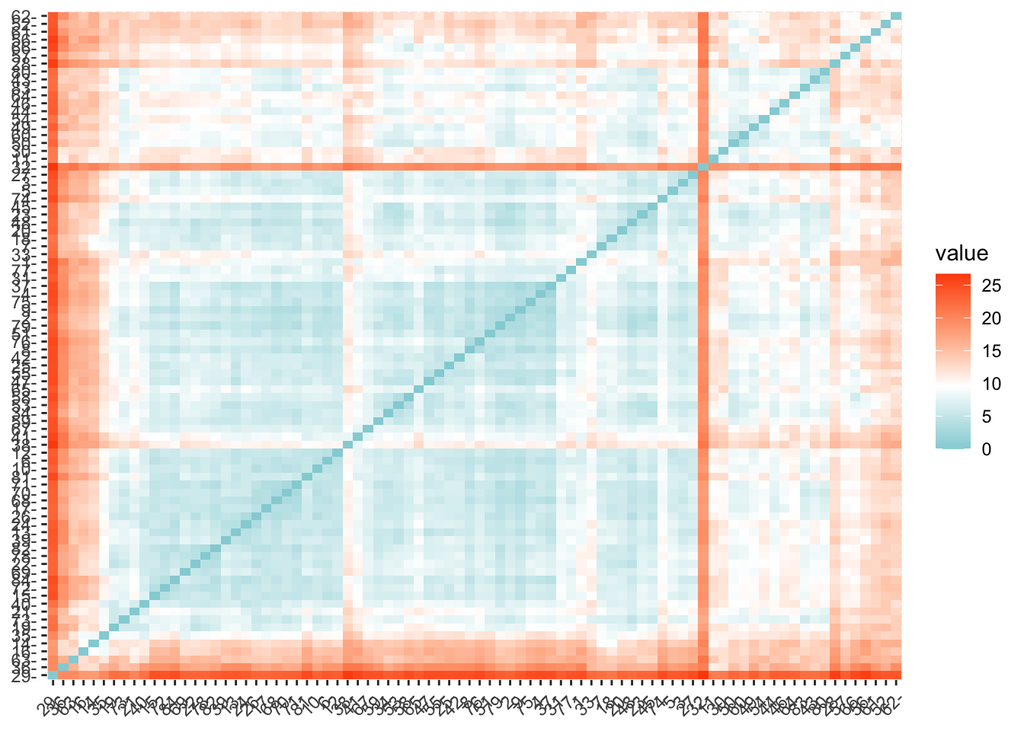

```r
distance <- get_dist(koboDentalEncoded)
fviz_dist(distance, gradient = list(low = "#00AFBB", mid = "white", high = "#FC4E07"))
```

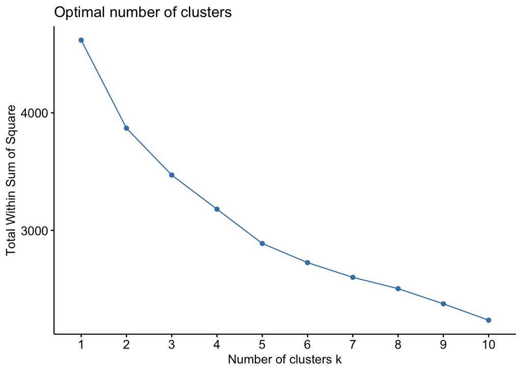

```r
fviz_nbclust(koboDentalEncoded, cluster::clara, method = "wss")
```

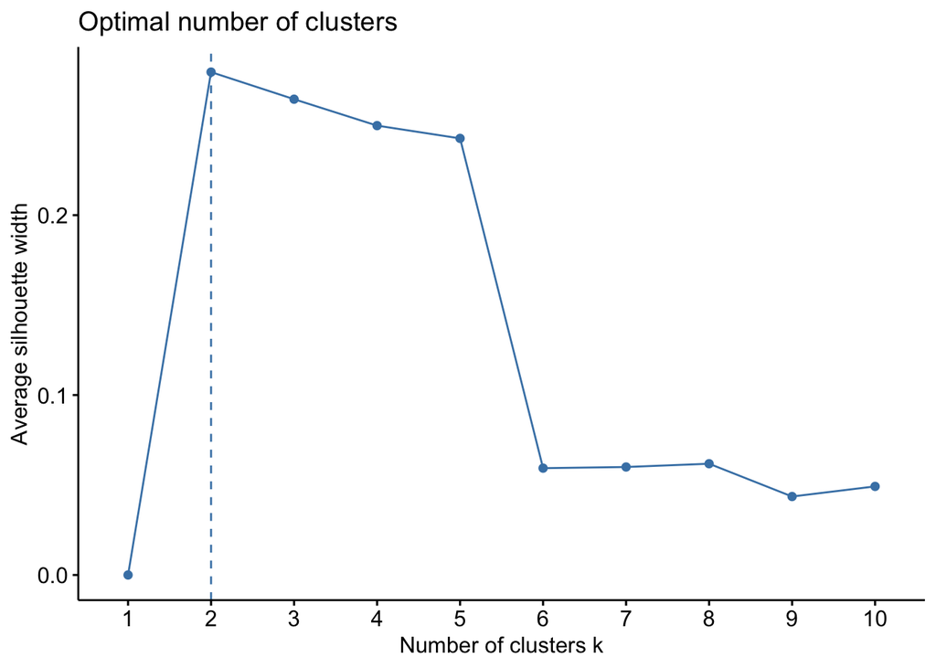

```r
fviz_nbclust(koboDentalEncoded, cluster::clara, method = "silhouette")
```

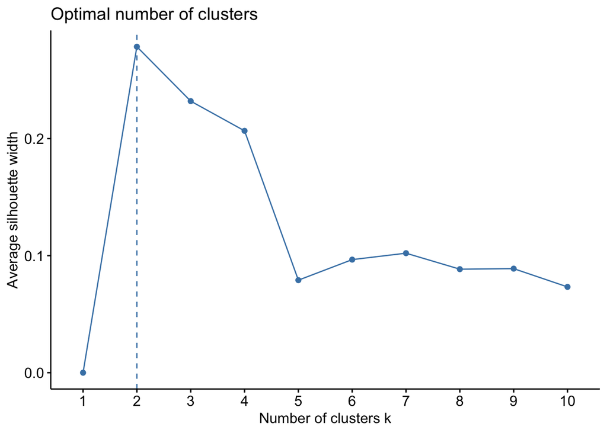

```r
fviz_nbclust(koboDentalEncoded, kmeans, method = "silhouette")
```

```r
k3 <- kmeans(koboDentalEncoded, centers = 2, nstart = 5)

summary(k3)
```

```
##              Length Class  Mode
## cluster       84    -none- numeric
## centers      126    -none- numeric
## totss          1    -none- numeric
## withinss       2    -none- numeric
## tot.withinss   1    -none- numeric
## betweenss      1    -none- numeric
## size           2    -none- numeric
## iter           1    -none- numeric
## ifault         1    -none- numeric
```

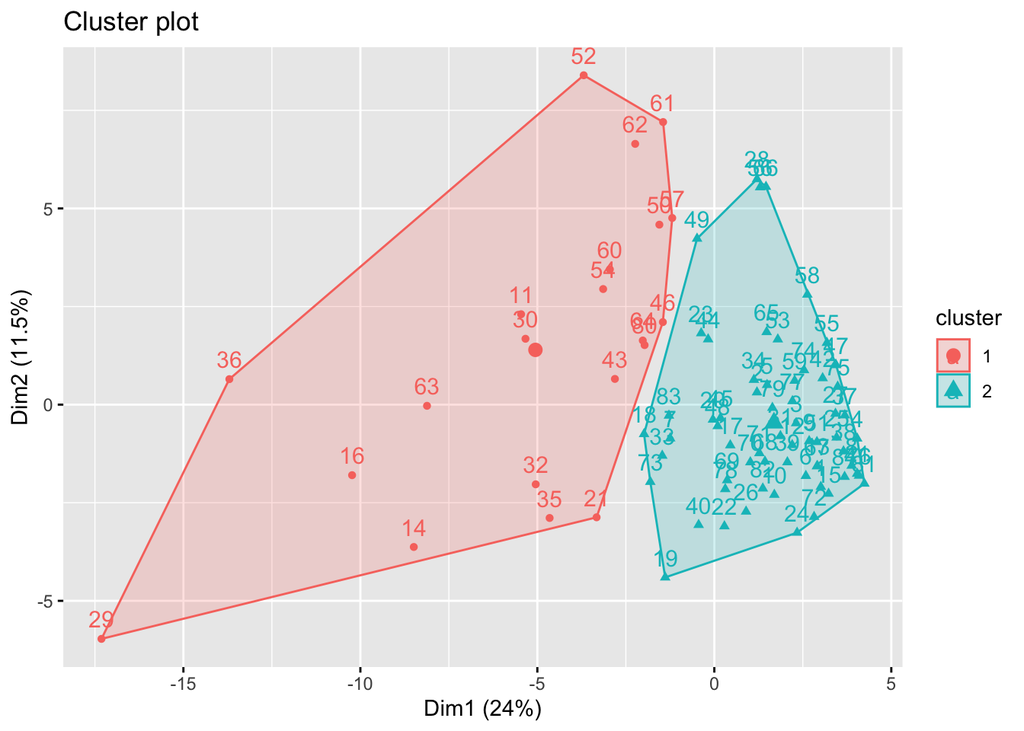

```r
fviz_cluster(k3, data = koboDentalEncoded)
```

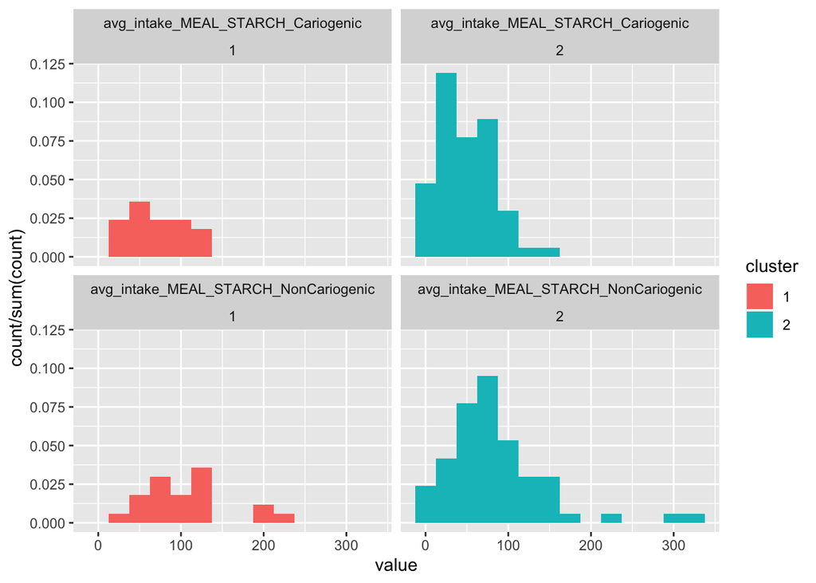

```r
koboDataK3Numeric <-
  combinedProfilesNutrients |>
  mutate(
    combined_icdas_score_2 = count_icdas_score_2_2 + count_icdas_score_2_3 + count_icdas_score_2_4 +
    count_icdas_score_2_5 + count_icdas_score_2_6) |>
  select(contains("avg_intake_MEAL"), contains("avg_intake_SNACK"), combined_icdas_score_2, participant_id) |>
  mutate(cluster = k3$cluster) |>
  select(where(is.numeric), participant_id, cluster) |>
  pivot_longer(cols=-c("participant_id", "cluster"), names_to = "variable") |>
#  filter(variable %in% colnames(koboDental)) |>
  mutate(cluster=as_factor(cluster))


ggplot(koboDataK3Numeric |> filter(str_starts(variable, "avg_intake_MEAL_STARCH") & !str_ends(variable, "Water") )) +
  geom_histogram(aes(x=value, y = after_stat(count / sum(count)), fill=cluster), binwidth = 25) +
  facet_wrap(~variable+cluster)
```

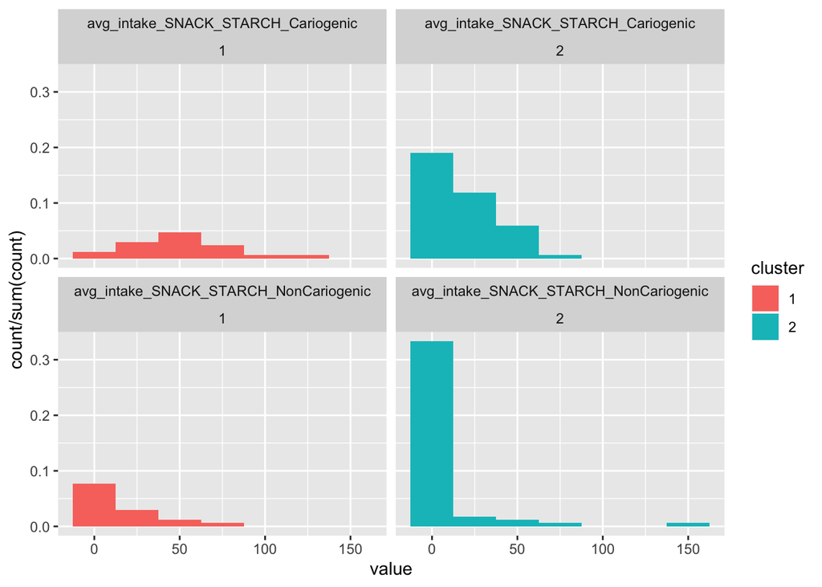

```r
ggplot(koboDataK3Numeric |> filter(str_starts(variable, "avg_intake_SNACK_STARCH") & !str_ends(variable, "Water") )) +
  geom_histogram(aes(x=value, y = after_stat(count / sum(count)), fill=cluster), binwidth = 25) +
  facet_wrap(~variable+cluster)
```

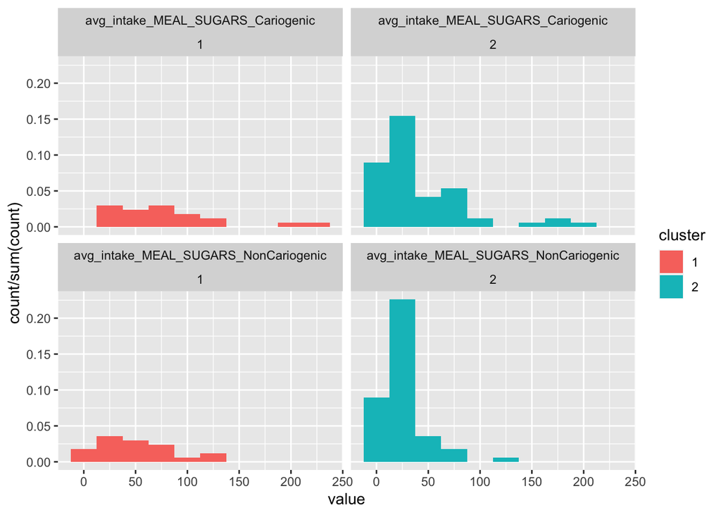

```r
ggplot(koboDataK3Numeric |> filter(str_starts(variable, "avg_intake_MEAL_SUGARS")  & !str_ends(variable, "Water") )) +
  geom_histogram(aes(x=value, y = after_stat(count / sum(count)), fill=cluster), binwidth = 25) +
  facet_wrap(~variable+cluster)
```

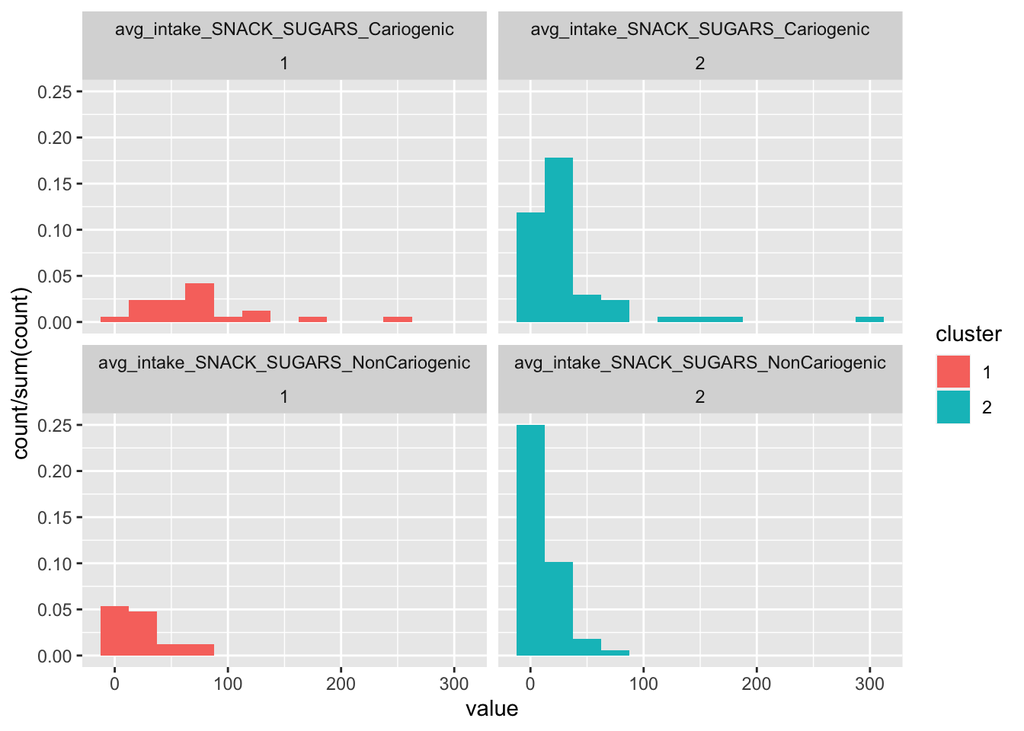

```r
ggplot(koboDataK3Numeric |> filter(str_starts(variable, "avg_intake_SNACK_SUGARS") & !str_ends(variable, "Water") )) +
  geom_histogram(aes(x=value, y = after_stat(count / sum(count)), fill=cluster), binwidth = 25) +
  facet_wrap(~variable+cluster)
```

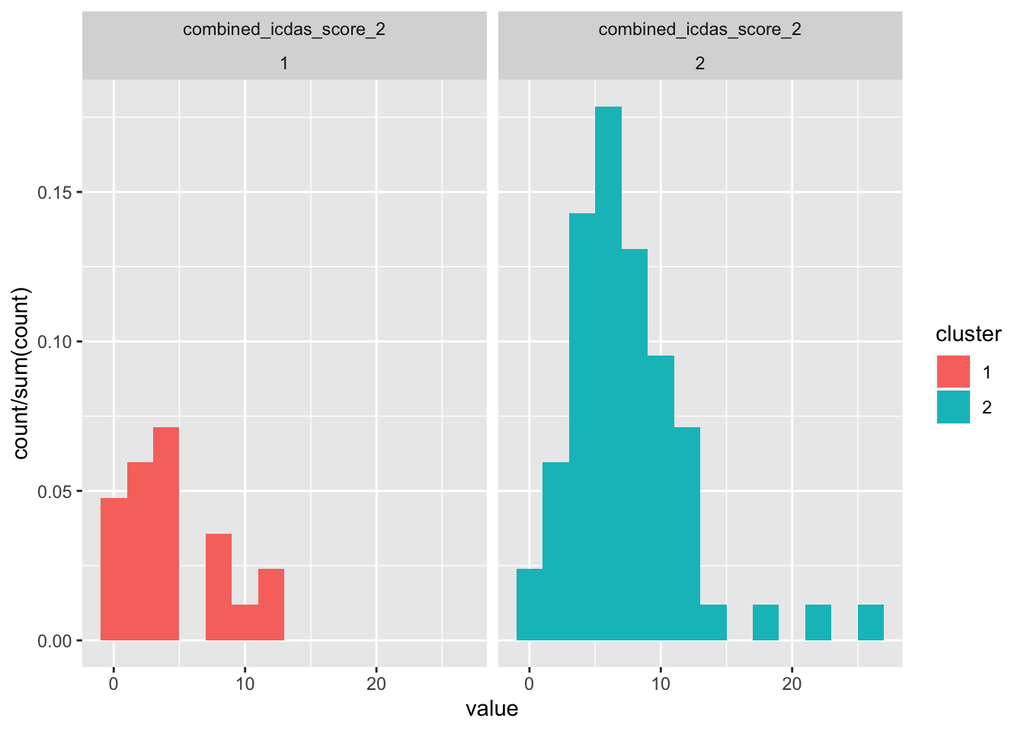

```r
ggplot(koboDataK3Numeric |> filter(str_starts(variable, "combined_icdas_score_2")  & !str_ends(variable, "Water") )) +
  geom_histogram(aes(x=value, y = after_stat(count / sum(count)), fill=cluster), binwidth = 2) +
  facet_wrap(~variable+cluster)
```

```r
library(nnet)
fbMeanStats <- colnames(fbIntakeNutrients)[grep(
  "avg_intake_MEAL_STARCH_Cariogenic|avg_intake_MEAL_STARCH_NonCariogenic|avg_intake_SNACK_STARCH_Cariogenic|avg_intake_SNACK_STARCH_NonCariogenic|avg_intake_MEAL_SUGARS_Cariogenic|avg_intake_MEAL_SUGARS_NonCariogenic|avg_intake_SNACK_SUGARS_Cariogenic",
  colnames(fbIntakeNutrients))]

lmData <- combinedProfilesNutrients |>
  mutate(cluster=as.factor(k3$cluster-1)) |>
  select(
         count_icdas_score_1_3,
         count_icdas_score_1_8,
         count_icdas_score_1_97,
         count_icdas_score_2_2,
         count_icdas_score_2_3,
         count_icdas_score_2_4,
         count_icdas_score_2_5,
         count_icdas_score_2_6,
         age,
         gender,
         all_of(fbMeanStats),

        cluster
) |>
  mutate(
  count_icdas_score_1 = count_icdas_score_1_3 + count_icdas_score_1_8 + count_icdas_score_1_97,
  count_icdas_score_2 = count_icdas_score_2_2 + count_icdas_score_2_3 + count_icdas_score_2_4 +
    count_icdas_score_2_5 + count_icdas_score_2_6
) |>
select(-c(count_icdas_score_1_3,
         count_icdas_score_1_8,
         count_icdas_score_1_97,
         count_icdas_score_2_2,
         count_icdas_score_2_3,
         count_icdas_score_2_4,
         count_icdas_score_2_5,
         count_icdas_score_2_6,
)) |>
  mutate(cluster = factor(cluster))

#model <- multinom(cluster~., data=lmData)
#summary(model)
#lmData <- koboDentalEncoded |> mutate(cluster=k3$cluster)

model = glm(cluster~., data = lmData, family = binomial)

summary(model)
```

```
##
## Call:
## glm(formula = cluster ~ ., family = binomial, data = lmData)
##
## Coefficients:
##                                        Estimate Std. Error z value Pr(>|z|)
## (Intercept)                            4.920843   3.462156   1.421  0.15522
## age                                    0.064110   0.119155   0.538  0.59055
## genderMale                            -0.417114   0.880574  -0.474  0.63573
## avg_intake_MEAL_STARCH_Cariogenic     -0.025068   0.014336  -1.749  0.08036 .
## avg_intake_MEAL_STARCH_NonCariogenic   0.007874   0.008158   0.965  0.33446
## avg_intake_MEAL_SUGARS_Cariogenic     -0.022723   0.010097  -2.250  0.02442 *
## avg_intake_MEAL_SUGARS_NonCariogenic  -0.052359   0.023117  -2.265  0.02351 *
## avg_intake_SNACK_STARCH_Cariogenic    -0.057039   0.019464  -2.930  0.00338 **
## avg_intake_SNACK_STARCH_NonCariogenic  0.014431   0.025878   0.558  0.57707
## avg_intake_SNACK_SUGARS_Cariogenic    -0.020231   0.007936  -2.549  0.01080 *
## count_icdas_score_1                   -0.274972   0.204267  -1.346  0.17826
## count_icdas_score_2                    0.303110   0.146598   2.068  0.03868 *
## ---
## Signif. codes:  0 '***' 0.001 '**' 0.01 '*' 0.05 '.' 0.1 ' ' 1
##
## (Dispersion parameter for binomial family taken to be 1)
##
##     Null deviance: 94.472  on 83  degrees of freedom
## Residual deviance: 42.440  on 72  degrees of freedom
## AIC: 66.44
##
## Number of Fisher Scoring iterations: 7
```

```r
model$residuals
```

```
##          1          2          3          4          5          6          7
##   1.000093   1.020228   1.035963   1.011684   1.002556   1.013888   1.060972
##          8          9         10         11         12         13         14
##   1.015239   1.017190   1.005640  -1.016383   1.000786   1.010713  -4.951072
##         15         16         17         18         19         20         21
##   1.034525  -1.183427   1.848160   2.259140   1.009828   1.035930  -1.528292
##         22         23         24         25         26         27         28
##   1.070364   2.226207   1.003675   1.028698   1.008441   1.000885   1.008962
##         29         30         31         32         33         34         35
##  -1.472444  -1.172427   1.000134 -15.194134   1.000551   1.375431  -3.005154
##         36         37         38         39         40         41         42
##  -1.061006   1.042191   1.001566   1.205200   1.028135   1.001272   1.011065
##         43         44         45         46         47         48         49
##  -2.281981   1.619580   1.006149  -1.406807   1.014097   1.011500   1.157274
##         50         51         52         53         54         55         56
##  -1.034687   1.003224  -1.000002   1.210066  -1.422475   1.016611   2.156889
##         57         58         59         60         61         62         63
##  -1.003399   1.087824   1.253641  -1.092666  -2.354684  -1.000102  -1.904918
##         64         65         66         67         68         69         70
##  -1.057980   1.083520   1.650216   1.000136  20.680497   1.098026   1.023185
##         71         72         73         74         75         76         77
##   1.049247   1.029562   1.014592   1.041902   1.058486   1.082725   1.208960
##         78         79         80         81         82         83         84
##   1.033239   1.012882  -4.016836   1.000616   1.489332   1.222725   1.004834
```